# Study 0 (replication) Analyses

NB referred to as Study 1 in manuscript

Ian Hussey & Jamie Cummins

24 June, 2022

```r
# dependencies
library(tidyverse)
library(sjPlot)
library(effsize)
library(psych)
library(knitr)
library(kableExtra)
library(plotrix)
library(Partiallyoverlapping)

# function to round all numeric vars in a data frame
round_df <- function(df, n_digits = 3) {
  # dependencies
  require(dplyr)

  df %>% mutate_if(is.numeric, round, digits = n_digits)
}


# get data
data_processed <- read_csv("../data/processed/processed_data.csv")

# exclusions
data_processed_exclusions <- data_processed %>%
  filter(complete_data == TRUE)
```

# Demographics

Analytic sample after exclusions.

```r
# Gender
data_processed_exclusions %>%
  mutate(gender = tolower(gender)) %>%
  dplyr::count(gender) %>%
  kable() %>%  # print nicer looking table
  kable_styling(bootstrap_options = c("striped", "hover", "condensed"), full_width = FALSE)
```

| gender | n |
| --- | --- |
| agender (afab) | 1 |
| cis female | 1 |
| f | 6 |
| female | 121 |
| girl | 1 |
| m | 5 |
| male | 155 |
| non-binary | 4 |
| woman | 1 |

```r
# Age mean and SD
data_processed_exclusions %>%
  mutate(age = as.numeric(as.character(age))) %>%
  summarise("age (mean)" = mean(age), "age (standard deviation)" = sd(age)) %>%
  round_df(2) %>%
  kable() %>%  # print nicer looking table
  kable_styling(bootstrap_options = c("striped", "hover", "condensed"), full_width = FALSE)
```

| age (mean) | age (standard deviation) |
| --- | --- |
| 29.81 | 10.29 |

# Hypothesis tests

## H1 (replication): Magnitude of Standard AMP effect compared to the skip-AMP effect

Payne et al. hypothesized that, if participants are influence-aware in the AMP, then AMP effects in the standard AMP should be larger than those of the skip AMP.

Some participants may skip all trials of the skip AMP, and thus have no scire. While they could simply be excluded in order to run a paired samples t-test, these values are Missing Not At Random - indeed, they are missing because of their extremely high influence rate. As such, their exclusion would distort results.

In order to overcome this, we employed a “partially overlapping t test”. Specifically, Derrick, Toher & White (2017) developed a method to assess partially overlapping samples. That is, neither a dependent nor independent t test, but a mixed t test containing some independent and some dependent data. Participants who demonstrated an influence rate of close to 100% have missing skip AMP effects. Their corresponding AMP effects are entered as independent data. Participants that have both AMP and skip AMP data are entered as dependent.

```r
# subset data
data_subset <- data_processed_exclusions %>%
  select(AMP_effect_positive_negative, skip_AMP_effect_positive_negative)

data_subset %>%
  summarise(mean_standard_effect = mean(AMP_effect_positive_negative),
            sd_standard_effect = sd(AMP_effect_positive_negative),
            mean_skip_effect = mean(skip_AMP_effect_positive_negative),
            sd_skip_effect = sd(skip_AMP_effect_positive_negative)) %>%
  round_df(2) %>%
  kable() %>%  # print nicer looking table
  kable_styling(bootstrap_options = c("striped", "hover", "condensed"), full_width = FALSE)
```

| mean_standard_effect | sd_standard_effect | mean_skip_effect | sd_skip_effect |
| --- | --- | --- | --- |
| 0.17 | 0.33 | -0.12 | 0.26 |

```r
Partover.test(x1 = pull(filter(data_subset, is.na(skip_AMP_effect_positive_negative)),
                        AMP_effect_positive_negative),
              x2 = pull(filter(data_subset, is.na(AMP_effect_positive_negative)),
                        skip_AMP_effect_positive_negative),
              x3 = pull(na.omit(data_subset),
                        AMP_effect_positive_negative),
              x4 = pull(na.omit(data_subset),
                        skip_AMP_effect_positive_negative),
              var.equal = FALSE) %>%
  unlist(.) %>%
  data.frame(value = .) %>%
  rownames_to_column(var = "key") %>%
  spread(key, value) %>%
  mutate(t = round(statistic, 2),
         df = round(parameter, 2),
         diff_in_means = round(estimate, 2)) %>%
  select(t, df, p = p.value, diff_in_means)
```

```
##      t  df           p diff_in_means
## 1 9.36 294 2.16352e-18          0.29
```

NB Cohen’s d estimates are imperfect as data either treat as independent when this is not the case. No partial overlap version of Cohen’s d exists to our knowledge. This estimate, and its CIs, is therefore likely to be biased and should be interpreted with caution. The hypothesis is tested using partially overlapping test, not the CIs on the effect size.

Between subjects cohen’s d:

```r
# gather subset
long_subset <- data_subset %>%
  gather(condition, score, c(AMP_effect_positive_negative, skip_AMP_effect_positive_negative))

effsize::cohen.d(score ~ condition,
                 paired = FALSE,
                 data = long_subset)
```

```
##
## Cohen's d
##
## d estimate: 0.9586234 (large)
## 95 percent confidence interval:
##     lower     upper
## 0.7878741 1.1293727
```

## H2: Does rate of skipping in the skip AMP predict standard AMP effects?

```r
h2_fit <-
  lm(AMP_effect_positive_negative ~ influence_rate,
     data = data_processed_exclusions)

tab_model(h2_fit, show.std = TRUE)
```

|  | AMP effect positive negative |  |  |  |  |
| --- | --- | --- | --- | --- | --- |
| Predictors | Estimates | std. Beta | CI | standardized CI | p |
| (Intercept) | 0.14 | 0.00 | 0.09 – 0.18 | -0.11 – 0.11 | **<0.001** |
| influence rate | 0.30 | 0.15 | 0.07 – 0.53 | 0.04 – 0.26 | **0.010** |
| Observations | 295 |  |  |  |  |
| R<sup>2</sup> / R<sup>2</sup> adjusted | 0.022 / 0.019 |  |  |  |  |

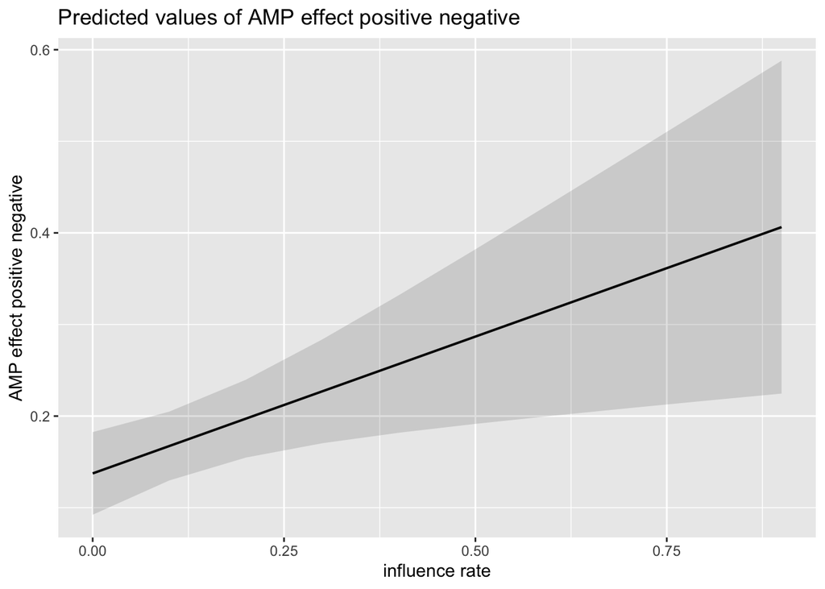

```r
plot_model(h2_fit, type = "pred")
```